# Project: Wrange and Analyze WeRateDogs

- Introduction
- Data Wrangling
- Data Gathering
- Data Assessing
- Data Cleaning
- Data Storing
- Analysis and Visualizations

## Introduction

In this project, we will go through the process of data wrangling from Twitter, specifically the Twitter user @dog_rates, and work on gathering and assessing define the quality, issues and tidiness of the data and clean and analysis and find out the insight.

## Data Wrangling

```python
import pandas as pd
import numpy as np
import requests
import tweepy
import json
import os
import seaborn as sns
import re
import time
import datetime
import matplotlib.pyplot as plt
%matplotlib inline
```

## Data Gathering

```python
#load CSV file into a DataFrame
df_archive=pd.read_csv('twitter-archive-enhanced.csv')
```

```python
df_archive.head()
```

|  | tweet_id | in_reply_to_status_id | in_reply_to_user_id | timestamp | source | text | retweeted_status_id | retweeted_status_user_id | retweeted_status_timestamp | expanded_urls | rating_numerator | rating_denominator | name | doggo | floofer | pupper | puppo |
| --- | --- | --- | --- | --- | --- | --- | --- | --- | --- | --- | --- | --- | --- | --- | --- | --- | --- |
| 0 | 8.924210e+17 | NaN | NaN | 2017-08-01 16:23:56 +0000 | <a href="http://twitter.com/download/iphone" r... | This is Phineas. He's a mystical boy. Only eve... | NaN | NaN | NaN | https://twitter.com/dog_rates/status/892420643... | 13 | 10 | Phineas | None | None | None | None |
| 1 | 8.921770e+17 | NaN | NaN | 2017-08-01 00:17:27 +0000 | <a href="http://twitter.com/download/iphone" r... | This is Tilly. She's just checking pup on you.... | NaN | NaN | NaN | https://twitter.com/dog_rates/status/892177421... | 13 | 10 | Tilly | None | None | None | None |
| 2 | 8.918150e+17 | NaN | NaN | 2017-07-31 00:18:03 +0000 | <a href="http://twitter.com/download/iphone" r... | This is Archie. He is a rare Norwegian Pouncin... | NaN | NaN | NaN | https://twitter.com/dog_rates/status/891815181... | 12 | 10 | Archie | None | None | None | None |
| 3 | 8.916900e+17 | NaN | NaN | 2017-07-30 15:58:51 +0000 | <a href="http://twitter.com/download/iphone" r... | This is Darla. She commenced a snooze mid meal... | NaN | NaN | NaN | https://twitter.com/dog_rates/status/891689557... | 13 | 10 | Darla | None | None | None | None |
| 4 | 8.913280e+17 | NaN | NaN | 2017-07-29 16:00:24 +0000 | <a href="http://twitter.com/download/iphone" r... | This is Franklin. He would like you to stop ca... | NaN | NaN | NaN | https://twitter.com/dog_rates/status/891327558... | 12 | 10 | Franklin | None | None | None | None |

```python
# load the TSV file into a DataFrame
df_image=pd.read_csv('image-predictions.tsv',sep="\t")
```

```python
df_image.head()
```

|  | tweet_id | jpg_url | img_num | p1 | p1_conf | p1_dog | p2 | p2_conf | p2_dog | p3 | p3_conf | p3_dog |
| --- | --- | --- | --- | --- | --- | --- | --- | --- | --- | --- | --- | --- |
| 0 | 666020888022790149 | https://pbs.twimg.com/media/CT4udn0WwAA0aMy.jpg | 1 | Welsh_springer_spaniel | 0.465074 | True | collie | 0.156665 | True | Shetland_sheepdog | 0.061428 | True |
| 1 | 666029285002620928 | https://pbs.twimg.com/media/CT42GRgUYAA5iDo.jpg | 1 | redbone | 0.506826 | True | miniature_pinscher | 0.074192 | True | Rhodesian_ridgeback | 0.072010 | True |
| 2 | 666033412701032449 | https://pbs.twimg.com/media/CT4521TWwAEvMyu.jpg | 1 | German_shepherd | 0.596461 | True | malinois | 0.138584 | True | bloodhound | 0.116197 | True |
| 3 | 666044226329800704 | https://pbs.twimg.com/media/CT5Dr8HUEAA-lEu.jpg | 1 | Rhodesian_ridgeback | 0.408143 | True | redbone | 0.360687 | True | miniature_pinscher | 0.222752 | True |
| 4 | 666049248165822465 | https://pbs.twimg.com/media/CT5IQmsXIAAKY4A.jpg | 1 | miniature_pinscher | 0.560311 | True | Rottweiler | 0.243682 | True | Doberman | 0.154629 | True |

```python
# Declare Twitter API keys and access tokens

consumer_key = 'XXXX'
consumer_secret = 'XXXX'
access_token = 'XXXX'
access_secret = 'XXXX'

auth = tweepy.OAuthHandler(consumer_key, consumer_secret)
auth.set_access_token(access_token, access_secret)

api = tweepy.API(auth,wait_on_rate_limit = True, wait_on_rate_limit_notify = True)
```

```python
# List of dictionaries to read tweet's JSON data line by line and later convert to a DataFrame
df_list = []
with open('tweet_json.txt', 'r', encoding='utf-8') as file:
    for line in file:
        title = json.loads(line)

        df_list.append({'tweet_id':title['id'],
                        'retweet_count':title['retweet_count'],
                        'favorite_count':title['favorite_count'],
                       'followers_count':title['user']['followers_count']})

# Create a DataFrame with tweet id, retweets count,followers_count and favorites

df_tweet = pd.DataFrame(df_list, columns = ['tweet_id','retweet_count', 'favorite_count','followers_count'])
```

```python
df_tweet.head()
```

|  | tweet_id | retweet_count | favorite_count | followers_count |
| --- | --- | --- | --- | --- |
| 0 | 892420643555336193 | 8853 | 39467 | 3200889 |
| 1 | 892177421306343426 | 6514 | 33819 | 3200889 |
| 2 | 891815181378084864 | 4328 | 25461 | 3200889 |
| 3 | 891689557279858688 | 8964 | 42908 | 3200889 |
| 4 | 891327558926688256 | 9774 | 41048 | 3200889 |

## Data Assessing

```python
df_archive.head()
```

|  | tweet_id | in_reply_to_status_id | in_reply_to_user_id | timestamp | source | text | retweeted_status_id | retweeted_status_user_id | retweeted_status_timestamp | expanded_urls | rating_numerator | rating_denominator | name | doggo | floofer | pupper | puppo |
| --- | --- | --- | --- | --- | --- | --- | --- | --- | --- | --- | --- | --- | --- | --- | --- | --- | --- |
| 0 | 8.924210e+17 | NaN | NaN | 2017-08-01 16:23:56 +0000 | <a href="http://twitter.com/download/iphone" r... | This is Phineas. He's a mystical boy. Only eve... | NaN | NaN | NaN | https://twitter.com/dog_rates/status/892420643... | 13 | 10 | Phineas | None | None | None | None |
| 1 | 8.921770e+17 | NaN | NaN | 2017-08-01 00:17:27 +0000 | <a href="http://twitter.com/download/iphone" r... | This is Tilly. She's just checking pup on you.... | NaN | NaN | NaN | https://twitter.com/dog_rates/status/892177421... | 13 | 10 | Tilly | None | None | None | None |
| 2 | 8.918150e+17 | NaN | NaN | 2017-07-31 00:18:03 +0000 | <a href="http://twitter.com/download/iphone" r... | This is Archie. He is a rare Norwegian Pouncin... | NaN | NaN | NaN | https://twitter.com/dog_rates/status/891815181... | 12 | 10 | Archie | None | None | None | None |
| 3 | 8.916900e+17 | NaN | NaN | 2017-07-30 15:58:51 +0000 | <a href="http://twitter.com/download/iphone" r... | This is Darla. She commenced a snooze mid meal... | NaN | NaN | NaN | https://twitter.com/dog_rates/status/891689557... | 13 | 10 | Darla | None | None | None | None |
| 4 | 8.913280e+17 | NaN | NaN | 2017-07-29 16:00:24 +0000 | <a href="http://twitter.com/download/iphone" r... | This is Franklin. He would like you to stop ca... | NaN | NaN | NaN | https://twitter.com/dog_rates/status/891327558... | 12 | 10 | Franklin | None | None | None | None |

```python
df_archive.info()
```

```
<class 'pandas.core.frame.DataFrame'>
RangeIndex: 2356 entries, 0 to 2355
Data columns (total 17 columns):
 #   Column                      Non-Null Count  Dtype
---  ------                      --------------  -----
 0   tweet_id                    2356 non-null   float64
 1   in_reply_to_status_id       78 non-null     float64
 2   in_reply_to_user_id         78 non-null     float64
 3   timestamp                   2356 non-null   object
 4   source                      2356 non-null   object
 5   text                        2356 non-null   object
 6   retweeted_status_id         181 non-null    float64
 7   retweeted_status_user_id    181 non-null    float64
 8   retweeted_status_timestamp  181 non-null    object
 9   expanded_urls               2297 non-null   object
 10  rating_numerator            2356 non-null   int64
 11  rating_denominator          2356 non-null   int64
 12  name                        2356 non-null   object
 13  doggo                       2356 non-null   object
 14  floofer                     2356 non-null   object
 15  pupper                      2356 non-null   object
 16  puppo                       2356 non-null   object
dtypes: float64(5), int64(2), object(10)
memory usage: 313.0+ KB
```

> df_archive (Twitter archive) table has 2356 rows and 17 columns in the DataFrame. Those are:
> - tweet_id: the unique identifier for each tweet
> - in_reply_to_status_id: if the referenced Tweet is a reply, this field will indicate the original Tweet's ID
> - n_reply_to_user_id: if the referenced Tweet is a reply, this field will indicate the original Tweet's author ID.
> - timestamp: date and time that the Tweet was published
> - source: app and hardware used to publish the Tweet
> - text: the text of the status update
> - retweeted_status_id: if the represented Tweet is a retweet, this field will contain the integer representation of the original Tweet’s ID
> - retweeted_status_user_id: if the represented Tweet is a retweet, this field will contain the integer representation of the original Tweet’s author ID
> - retweeted_status_timestamp: time of retweet
> - expanded_urls: tweet URL
> - rating_numerator: numerator of the rating of a dog. Note: ratings almost always greater than 10
> - rating_denominator: denominator of the rating of a dog. Note: ratings almost always have a denominator of 10
> - name: name of the dog
> - doggo: one of the 4 dog "stage"
> - floofer: one of the 4 dog "stage"
> - pupper: one of the 4 dog "stage"
> - puppo: one of the 4 dog "stage"

```python
df_image.head()
```

|  | tweet_id | jpg_url | img_num | p1 | p1_conf | p1_dog | p2 | p2_conf | p2_dog | p3 | p3_conf | p3_dog |
| --- | --- | --- | --- | --- | --- | --- | --- | --- | --- | --- | --- | --- |
| 0 | 666020888022790149 | https://pbs.twimg.com/media/CT4udn0WwAA0aMy.jpg | 1 | Welsh_springer_spaniel | 0.465074 | True | collie | 0.156665 | True | Shetland_sheepdog | 0.061428 | True |
| 1 | 666029285002620928 | https://pbs.twimg.com/media/CT42GRgUYAA5iDo.jpg | 1 | redbone | 0.506826 | True | miniature_pinscher | 0.074192 | True | Rhodesian_ridgeback | 0.072010 | True |
| 2 | 666033412701032449 | https://pbs.twimg.com/media/CT4521TWwAEvMyu.jpg | 1 | German_shepherd | 0.596461 | True | malinois | 0.138584 | True | bloodhound | 0.116197 | True |
| 3 | 666044226329800704 | https://pbs.twimg.com/media/CT5Dr8HUEAA-lEu.jpg | 1 | Rhodesian_ridgeback | 0.408143 | True | redbone | 0.360687 | True | miniature_pinscher | 0.222752 | True |
| 4 | 666049248165822465 | https://pbs.twimg.com/media/CT5IQmsXIAAKY4A.jpg | 1 | miniature_pinscher | 0.560311 | True | Rottweiler | 0.243682 | True | Doberman | 0.154629 | True |

```python
df_image.info()
```

```
<class 'pandas.core.frame.DataFrame'>
RangeIndex: 2075 entries, 0 to 2074
Data columns (total 12 columns):
 #   Column    Non-Null Count  Dtype
---  ------    --------------  -----
 0   tweet_id  2075 non-null   int64
 1   jpg_url   2075 non-null   object
 2   img_num   2075 non-null   int64
 3   p1        2075 non-null   object
 4   p1_conf   2075 non-null   float64
 5   p1_dog    2075 non-null   bool
 6   p2        2075 non-null   object
 7   p2_conf   2075 non-null   float64
 8   p2_dog    2075 non-null   bool
 9   p3        2075 non-null   object
 10  p3_conf   2075 non-null   float64
 11  p3_dog    2075 non-null   bool
dtypes: bool(3), float64(3), int64(2), object(4)
memory usage: 152.1+ KB
```

> df_image (tweet image predictions) table has 2075 rows and 12 columns in the DataFrame. Those are:
> - tweet_id: the unique identifier for each tweet
> - jpg_url: dog's image URL
> - img_num: the image number that matches the most confident prediction, from 1 to 4
> - p1: the algorithm's first choice to predict the image in the tweet
> - p1_conf: how confident the algorithm is that the image is a breed of dog, in percentage
> - p1_dog: true or false, if the predicition is indeed a breed of dog
> - p2: algorithm's second most likely prediction
> - p2_conf: how confident the algorithm is that the image is a breed of dog, in percentage
> - p2_dog: true or false, if the predicition is indeed a breed of dog
> - p3: algorithm's third prediction for the image in the tweet
> - p3_conf: how confident the algorithm is that the image is a breed of dog, in percentage
> - p3_dog: true or false, if the predicition is indeed a breed of dog

```python
df_tweet.head()
```

|  | tweet_id | retweet_count | favorite_count | followers_count |
| --- | --- | --- | --- | --- |
| 0 | 892420643555336193 | 8853 | 39467 | 3200889 |
| 1 | 892177421306343426 | 6514 | 33819 | 3200889 |
| 2 | 891815181378084864 | 4328 | 25461 | 3200889 |
| 3 | 891689557279858688 | 8964 | 42908 | 3200889 |
| 4 | 891327558926688256 | 9774 | 41048 | 3200889 |

```python
df_tweet.info()
```

```
<class 'pandas.core.frame.DataFrame'>
RangeIndex: 2354 entries, 0 to 2353
Data columns (total 4 columns):
 #   Column           Non-Null Count  Dtype
---  ------           --------------  -----
 0   tweet_id         2354 non-null   int64
 1   retweet_count    2354 non-null   int64
 2   favorite_count   2354 non-null   int64
 3   followers_count  2354 non-null   int64
dtypes: int64(4)
memory usage: 73.7 KB
```

> df_tweet (tweet status) table has 2354 rows and I have chosen 4 columns of interest to include in the DataFrame. Those are:
> - tweet_id: the unique identifier for each tweet
> - retweet_count: number of times this Tweet has been retweeted
> - favorite_count: number of likes
> - followers_count: number of followers

### Tidiness Issues

- Merging the three dataframes, using the common tweet_id
- The puppo/doggo/floofer/pupper terms in df_archive table should be merged into one column named "dog_stage"

## Data Cleaning

```python
#Make copies of the originals
df2_archive = df_archive.copy()
df2_image = df_image.copy()
df2_tweet = df_tweet.copy()
```

### Tidiness Issue # 1

### Define: Merge dataframes

Use .merge() to create one large dataframe from the three available dataframes.

### Code

```python
# Join df2_archive and df2_image
df = pd.merge(df2_archive, df2_image,on='tweet_id', how='left')
```

```python
#Join df2_tweet to df
master = pd.merge(df, df2_tweet, on='tweet_id', how='left')
```

### Test

```python
#test the merge
master.info()
```

```
<class 'pandas.core.frame.DataFrame'>
Int64Index: 2356 entries, 0 to 2355
Data columns (total 31 columns):
 #   Column                      Non-Null Count  Dtype
---  ------                      --------------  -----
 0   tweet_id                    2356 non-null   float64
 1   in_reply_to_status_id       78 non-null     float64
 2   in_reply_to_user_id         78 non-null     float64
 3   timestamp                   2356 non-null   object
 4   source                      2356 non-null   object
 5   text                        2356 non-null   object
 6   retweeted_status_id         181 non-null    float64
 7   retweeted_status_user_id    181 non-null    float64
 8   retweeted_status_timestamp  181 non-null    object
 9   expanded_urls               2297 non-null   object
```

[output cut: 23 more lines]

```python
master.head(5)
```

|  | tweet_id | in_reply_to_status_id | in_reply_to_user_id | timestamp | source | text | retweeted_status_id | retweeted_status_user_id | retweeted_status_timestamp | expanded_urls | ... | p1_dog | p2 | p2_conf | p2_dog | p3 | p3_conf | p3_dog | retweet_count | favorite_count | followers_count |
| --- | --- | --- | --- | --- | --- | --- | --- | --- | --- | --- | --- | --- | --- | --- | --- | --- | --- | --- | --- | --- | --- |
| 0 | 8.924210e+17 | NaN | NaN | 2017-08-01 16:23:56 +0000 | <a href="http://twitter.com/download/iphone" r... | This is Phineas. He's a mystical boy. Only eve... | NaN | NaN | NaN | https://twitter.com/dog_rates/status/892420643... | ... | NaN | NaN | NaN | NaN | NaN | NaN | NaN | NaN | NaN | NaN |
| 1 | 8.921770e+17 | NaN | NaN | 2017-08-01 00:17:27 +0000 | <a href="http://twitter.com/download/iphone" r... | This is Tilly. She's just checking pup on you.... | NaN | NaN | NaN | https://twitter.com/dog_rates/status/892177421... | ... | NaN | NaN | NaN | NaN | NaN | NaN | NaN | NaN | NaN | NaN |
| 2 | 8.918150e+17 | NaN | NaN | 2017-07-31 00:18:03 +0000 | <a href="http://twitter.com/download/iphone" r... | This is Archie. He is a rare Norwegian Pouncin... | NaN | NaN | NaN | https://twitter.com/dog_rates/status/891815181... | ... | NaN | NaN | NaN | NaN | NaN | NaN | NaN | NaN | NaN | NaN |
| 3 | 8.916900e+17 | NaN | NaN | 2017-07-30 15:58:51 +0000 | <a href="http://twitter.com/download/iphone" r... | This is Darla. She commenced a snooze mid meal... | NaN | NaN | NaN | https://twitter.com/dog_rates/status/891689557... | ... | NaN | NaN | NaN | NaN | NaN | NaN | NaN | NaN | NaN | NaN |
| 4 | 8.913280e+17 | NaN | NaN | 2017-07-29 16:00:24 +0000 | <a href="http://twitter.com/download/iphone" r... | This is Franklin. He would like you to stop ca... | NaN | NaN | NaN | https://twitter.com/dog_rates/status/891327558... | ... | NaN | NaN | NaN | NaN | NaN | NaN | NaN | NaN | NaN | NaN |

5 rows × 31 columns

### Tidiness Issue # 2

### Define: Dog stages into one column

Merge the doggo, floofer, pupper and puppo columns to one a dog_stage column

### Code

```python
# merge the doggo, floofer, pupper and puppo columns to a dog_stage column
master['dog_stage'] = master[['doggo', 'floofer', 'pupper', 'puppo']].max(axis=1)
```

```python
# convert the datatype from string to categorical
master.dog_stage = master.dog_stage.astype('category')
```

```python
# drop the doggo, floofer, pupper and puppo columns
master.drop(['doggo', 'floofer', 'pupper', 'puppo'], axis=1, inplace=True)
```

### Test

```python
master.info()
```

```
<class 'pandas.core.frame.DataFrame'>
Int64Index: 2356 entries, 0 to 2355
Data columns (total 28 columns):
 #   Column                      Non-Null Count  Dtype
---  ------                      --------------  -----
 0   tweet_id                    2356 non-null   float64
 1   in_reply_to_status_id       78 non-null     float64
 2   in_reply_to_user_id         78 non-null     float64
 3   timestamp                   2356 non-null   object
 4   source                      2356 non-null   object
 5   text                        2356 non-null   object
 6   retweeted_status_id         181 non-null    float64
 7   retweeted_status_user_id    181 non-null    float64
 8   retweeted_status_timestamp  181 non-null    object
 9   expanded_urls               2297 non-null   object
```

[output cut: 20 more lines]

```python
master.head()
```

|  | tweet_id | in_reply_to_status_id | in_reply_to_user_id | timestamp | source | text | retweeted_status_id | retweeted_status_user_id | retweeted_status_timestamp | expanded_urls | ... | p2 | p2_conf | p2_dog | p3 | p3_conf | p3_dog | retweet_count | favorite_count | followers_count | dog_stage |
| --- | --- | --- | --- | --- | --- | --- | --- | --- | --- | --- | --- | --- | --- | --- | --- | --- | --- | --- | --- | --- | --- |
| 0 | 8.924210e+17 | NaN | NaN | 2017-08-01 16:23:56 +0000 | <a href="http://twitter.com/download/iphone" r... | This is Phineas. He's a mystical boy. Only eve... | NaN | NaN | NaN | https://twitter.com/dog_rates/status/892420643... | ... | NaN | NaN | NaN | NaN | NaN | NaN | NaN | NaN | NaN | None |
| 1 | 8.921770e+17 | NaN | NaN | 2017-08-01 00:17:27 +0000 | <a href="http://twitter.com/download/iphone" r... | This is Tilly. She's just checking pup on you.... | NaN | NaN | NaN | https://twitter.com/dog_rates/status/892177421... | ... | NaN | NaN | NaN | NaN | NaN | NaN | NaN | NaN | NaN | None |
| 2 | 8.918150e+17 | NaN | NaN | 2017-07-31 00:18:03 +0000 | <a href="http://twitter.com/download/iphone" r... | This is Archie. He is a rare Norwegian Pouncin... | NaN | NaN | NaN | https://twitter.com/dog_rates/status/891815181... | ... | NaN | NaN | NaN | NaN | NaN | NaN | NaN | NaN | NaN | None |
| 3 | 8.916900e+17 | NaN | NaN | 2017-07-30 15:58:51 +0000 | <a href="http://twitter.com/download/iphone" r... | This is Darla. She commenced a snooze mid meal... | NaN | NaN | NaN | https://twitter.com/dog_rates/status/891689557... | ... | NaN | NaN | NaN | NaN | NaN | NaN | NaN | NaN | NaN | None |
| 4 | 8.913280e+17 | NaN | NaN | 2017-07-29 16:00:24 +0000 | <a href="http://twitter.com/download/iphone" r... | This is Franklin. He would like you to stop ca... | NaN | NaN | NaN | https://twitter.com/dog_rates/status/891327558... | ... | NaN | NaN | NaN | NaN | NaN | NaN | NaN | NaN | NaN | None |

5 rows × 28 columns

### Quality Issue # 1

### Define: Delete extraneous columns

Some columns contain information that will not be needed for my analysis. These include 'in_reply_to_status_id', 'in_reply_to_user_id', 'source', 'retweeted_status_id', 'retweeted_status_user_id', 'retweeted_status_timestamp', 'p2_conf', 'p2_dog', 'p3_conf', and 'p3_dog'.

```python
#a reminder of the columns
master.info()
```

```
<class 'pandas.core.frame.DataFrame'>
Int64Index: 2356 entries, 0 to 2355
Data columns (total 28 columns):
 #   Column                      Non-Null Count  Dtype
---  ------                      --------------  -----
 0   tweet_id                    2356 non-null   float64
 1   in_reply_to_status_id       78 non-null     float64
 2   in_reply_to_user_id         78 non-null     float64
 3   timestamp                   2356 non-null   object
 4   source                      2356 non-null   object
 5   text                        2356 non-null   object
 6   retweeted_status_id         181 non-null    float64
 7   retweeted_status_user_id    181 non-null    float64
 8   retweeted_status_timestamp  181 non-null    object
 9   expanded_urls               2297 non-null   object
```

[output cut: 20 more lines]

### Code

```python
## drop the columns
master.drop(['in_reply_to_status_id', 'in_reply_to_user_id', 'source', 'retweeted_status_id', 'retweeted_status_user_id', 'retweeted_status_timestamp', 'p2_conf', 'p2_dog', 'p3_conf', 'p3_dog'], axis = 1, inplace = True)
```

### Test

```python
# test
master.info()
```

```
<class 'pandas.core.frame.DataFrame'>
Int64Index: 2356 entries, 0 to 2355
Data columns (total 18 columns):
 #   Column              Non-Null Count  Dtype
---  ------              --------------  -----
 0   tweet_id            2356 non-null   float64
 1   timestamp           2356 non-null   object
 2   text                2356 non-null   object
 3   expanded_urls       2297 non-null   object
 4   rating_numerator    2356 non-null   int64
 5   rating_denominator  2356 non-null   int64
 6   name                2356 non-null   object
 7   jpg_url             0 non-null      object
 8   img_num             0 non-null      float64
 9   p1                  0 non-null      object
 10  p1_conf             0 non-null      float64
 11  p1_dog              0 non-null      object
 12  p2                  0 non-null      object
 13  p3                  0 non-null      object
 14  retweet_count       0 non-null      float64
 15  favorite_count      0 non-null      float64
 16  followers_count     0 non-null      float64
 17  dog_stage           2356 non-null   category
dtypes: category(1), float64(6), int64(2), object(9)
memory usage: 333.8+ KB
```

### Quality Issue # 2

### Define: convert the data types for 'tweet_id' to string

As an identifier, this column as a string would serve our purposes better than as a number.

### Code

```python
# Convert tweet_id from int to string
master['tweet_id'] = master['tweet_id'].astype('str')
```

### Test

```python
#test
master.info()
```

```
<class 'pandas.core.frame.DataFrame'>
Int64Index: 2356 entries, 0 to 2355
Data columns (total 18 columns):
 #   Column              Non-Null Count  Dtype
---  ------              --------------  -----
 0   tweet_id            2356 non-null   object
 1   timestamp           2356 non-null   object
 2   text                2356 non-null   object
 3   expanded_urls       2297 non-null   object
 4   rating_numerator    2356 non-null   int64
 5   rating_denominator  2356 non-null   int64
 6   name                2356 non-null   object
 7   jpg_url             0 non-null      object
 8   img_num             0 non-null      float64
 9   p1                  0 non-null      object
 10  p1_conf             0 non-null      float64
 11  p1_dog              0 non-null      object
 12  p2                  0 non-null      object
 13  p3                  0 non-null      object
 14  retweet_count       0 non-null      float64
 15  favorite_count      0 non-null      float64
 16  followers_count     0 non-null      float64
 17  dog_stage           2356 non-null   category
dtypes: category(1), float64(5), int64(2), object(10)
memory usage: 333.8+ KB
```

### Quality Issue # 3

### Define: Convert the data types for 'timestamp' to datetime

The datetime datatype is more appropriate type for this column.

### Code

```python
# Convert timestamp from string to datetime
master['timestamp'] = master['timestamp'].astype('datetime64')
```

### Test

```python
#test
master.info()
```

```
<class 'pandas.core.frame.DataFrame'>
Int64Index: 2356 entries, 0 to 2355
Data columns (total 18 columns):
 #   Column              Non-Null Count  Dtype
---  ------              --------------  -----
 0   tweet_id            2356 non-null   object
 1   timestamp           2356 non-null   datetime64[ns]
 2   text                2356 non-null   object
 3   expanded_urls       2297 non-null   object
 4   rating_numerator    2356 non-null   int64
 5   rating_denominator  2356 non-null   int64
 6   name                2356 non-null   object
 7   jpg_url             0 non-null      object
 8   img_num             0 non-null      float64
 9   p1                  0 non-null      object
 10  p1_conf             0 non-null      float64
 11  p1_dog              0 non-null      object
 12  p2                  0 non-null      object
 13  p3                  0 non-null      object
 14  retweet_count       0 non-null      float64
 15  favorite_count      0 non-null      float64
 16  followers_count     0 non-null      float64
 17  dog_stage           2356 non-null   category
dtypes: category(1), datetime64[ns](1), float64(5), int64(2), object(9)
memory usage: 333.8+ KB
```

```python
master.head()
```

|  | tweet_id | timestamp | text | expanded_urls | rating_numerator | rating_denominator | name | jpg_url | img_num | p1 | p1_conf | p1_dog | p2 | p3 | retweet_count | favorite_count | followers_count | dog_stage |
| --- | --- | --- | --- | --- | --- | --- | --- | --- | --- | --- | --- | --- | --- | --- | --- | --- | --- | --- |
| 0 | 8.92421e+17 | 2017-08-01 16:23:56 | This is Phineas. He's a mystical boy. Only eve... | https://twitter.com/dog_rates/status/892420643... | 13 | 10 | Phineas | NaN | NaN | NaN | NaN | NaN | NaN | NaN | NaN | NaN | NaN | None |
| 1 | 8.92177e+17 | 2017-08-01 00:17:27 | This is Tilly. She's just checking pup on you.... | https://twitter.com/dog_rates/status/892177421... | 13 | 10 | Tilly | NaN | NaN | NaN | NaN | NaN | NaN | NaN | NaN | NaN | NaN | None |
| 2 | 8.91815e+17 | 2017-07-31 00:18:03 | This is Archie. He is a rare Norwegian Pouncin... | https://twitter.com/dog_rates/status/891815181... | 12 | 10 | Archie | NaN | NaN | NaN | NaN | NaN | NaN | NaN | NaN | NaN | NaN | None |
| 3 | 8.9169e+17 | 2017-07-30 15:58:51 | This is Darla. She commenced a snooze mid meal... | https://twitter.com/dog_rates/status/891689557... | 13 | 10 | Darla | NaN | NaN | NaN | NaN | NaN | NaN | NaN | NaN | NaN | NaN | None |
| 4 | 8.91328e+17 | 2017-07-29 16:00:24 | This is Franklin. He would like you to stop ca... | https://twitter.com/dog_rates/status/891327558... | 12 | 10 | Franklin | NaN | NaN | NaN | NaN | NaN | NaN | NaN | NaN | NaN | NaN | None |

### Quality Issue # 4

### Define: Change the data types for img_num to category

The 'img_num' columns will function appopriately as a category type.

### Code

```python
master.img_num = master.img_num.astype('category')
```

### Test

```python
#test
master.info()
```

```
<class 'pandas.core.frame.DataFrame'>
Int64Index: 2356 entries, 0 to 2355
Data columns (total 18 columns):
 #   Column              Non-Null Count  Dtype
---  ------              --------------  -----
 0   tweet_id            2356 non-null   object
 1   timestamp           2356 non-null   datetime64[ns]
 2   text                2356 non-null   object
 3   expanded_urls       2297 non-null   object
 4   rating_numerator    2356 non-null   int64
 5   rating_denominator  2356 non-null   int64
 6   name                2356 non-null   object
 7   jpg_url             0 non-null      object
 8   img_num             0 non-null      category
 9   p1                  0 non-null      object
 10  p1_conf             0 non-null      float64
 11  p1_dog              0 non-null      object
 12  p2                  0 non-null      object
 13  p3                  0 non-null      object
 14  retweet_count       0 non-null      float64
 15  favorite_count      0 non-null      float64
 16  followers_count     0 non-null      float64
 17  dog_stage           2356 non-null   category
dtypes: category(2), datetime64[ns](1), float64(4), int64(2), object(9)
memory usage: 317.8+ KB
```

### Quality Issue # 5

### Define: Remove Tweets without Images for the expanded_urls column

Tweets without the dog images are not necessary for this analysis.

### Code

```python
master['expanded_urls'].isnull().value_counts()
```

```
False    2297
True       59
Name: expanded_urls, dtype: int64
```

```python
master = master.dropna(subset=['expanded_urls'])
```

### Test

```python
master['expanded_urls'].isnull().value_counts()
```

```
False    2297
Name: expanded_urls, dtype: int64
```

### Quality Issue # 6

### Define: Remove Tweets that the rating denominator not equal 10

Tweets without rating denominator 10 are not accurate and not necessary for this analysis.As these ratings almost always have a denominator of 10

### Code

```python
# find and drop the raw where the rating_denominator less or greater than 10
master.rating_denominator.value_counts()
```

```
10     2278
11        3
50        3
80        2
7         1
170       1
150       1
130       1
120       1
110       1
90        1
70        1
40        1
20        1
2         1
Name: rating_denominator, dtype: int64
```

```python
master[master.rating_denominator != 10]
```

|  | tweet_id | timestamp | text | expanded_urls | rating_numerator | rating_denominator | name | jpg_url | img_num | p1 | p1_conf | p1_dog | p2 | p3 | retweet_count | favorite_count | followers_count | dog_stage |
| --- | --- | --- | --- | --- | --- | --- | --- | --- | --- | --- | --- | --- | --- | --- | --- | --- | --- | --- |
| 433 | 8.2069e+17 | 2017-01-15 17:52:40 | The floofs have been released I repeat the flo... | https://twitter.com/dog_rates/status/820690176... | 84 | 70 | None | NaN | NaN | NaN | NaN | NaN | NaN | NaN | NaN | NaN | NaN | None |
| 516 | 8.10985e+17 | 2016-12-19 23:06:23 | Meet Sam. She smiles 24/7 &amp; secretly aspir... | https://www.gofundme.com/sams-smile,https://tw... | 24 | 7 | Sam | NaN | NaN | NaN | NaN | NaN | NaN | NaN | NaN | NaN | NaN | None |
| 784 | 7.75097e+17 | 2016-09-11 22:20:06 | RT @dog_rates: After so many requests, this is... | https://twitter.com/dog_rates/status/740373189... | 9 | 11 | None | NaN | NaN | NaN | NaN | NaN | NaN | NaN | NaN | NaN | NaN | None |
| 902 | 7.58467e+17 | 2016-07-28 01:00:57 | Why does this never happen at my front door...... | https://twitter.com/dog_rates/status/758467244... | 165 | 150 | None | NaN | NaN | NaN | NaN | NaN | NaN | NaN | NaN | NaN | NaN | None |
| 1068 | 7.40373e+17 | 2016-06-08 02:41:38 | After so many requests, this is Bretagne. She ... | https://twitter.com/dog_rates/status/740373189... | 9 | 11 | None | NaN | NaN | NaN | NaN | NaN | NaN | NaN | NaN | NaN | NaN | None |
| 1120 | 7.31156e+17 | 2016-05-13 16:15:54 | Say hello to this unbelievably well behaved sq... | https://twitter.com/dog_rates/status/731156023... | 204 | 170 | this | NaN | NaN | NaN | NaN | NaN | NaN | NaN | NaN | NaN | NaN | None |
| 1165 | 7.22975e+17 | 2016-04-21 02:25:47 | Happy 4/20 from the squad! 13/10 for all https... | https://twitter.com/dog_rates/status/722974582... | 4 | 20 | None | NaN | NaN | NaN | NaN | NaN | NaN | NaN | NaN | NaN | NaN | None |
| 1202 | 7.16439e+17 | 2016-04-03 01:36:11 | This is Bluebert. He just saw that both #Final... | https://twitter.com/dog_rates/status/716439118... | 50 | 50 | Bluebert | NaN | NaN | NaN | NaN | NaN | NaN | NaN | NaN | NaN | NaN | None |
| 1228 | 7.13901e+17 | 2016-03-27 01:29:02 | Happy Saturday here's 9 puppers on a bench. 99... | https://twitter.com/dog_rates/status/713900603... | 99 | 90 | None | NaN | NaN | NaN | NaN | NaN | NaN | NaN | NaN | NaN | NaN | None |
| 1254 | 7.10659e+17 | 2016-03-18 02:46:49 | Here's a brigade of puppers. All look very pre... | https://twitter.com/dog_rates/status/710658690... | 80 | 80 | None | NaN | NaN | NaN | NaN | NaN | NaN | NaN | NaN | NaN | NaN | None |
| 1274 | 7.09198e+17 | 2016-03-14 02:04:08 | From left to right:\nCletus, Jerome, Alejandro... | https://twitter.com/dog_rates/status/709198395... | 45 | 50 | None | NaN | NaN | NaN | NaN | NaN | NaN | NaN | NaN | NaN | NaN | None |
| 1351 | 7.04055e+17 | 2016-02-28 21:25:30 | Here is a whole flock of puppers. 60/50 I'll ... | https://twitter.com/dog_rates/status/704054845... | 60 | 50 | a | NaN | NaN | NaN | NaN | NaN | NaN | NaN | NaN | NaN | NaN | None |
| 1433 | 6.97463e+17 | 2016-02-10 16:51:59 | Happy Wednesday here's a bucket of pups. 44/40... | https://twitter.com/dog_rates/status/697463031... | 44 | 40 | None | NaN | NaN | NaN | NaN | NaN | NaN | NaN | NaN | NaN | NaN | None |
| 1634 | 6.84226e+17 | 2016-01-05 04:11:44 | Two sneaky puppers were not initially seen, mo... | https://twitter.com/dog_rates/status/684225744... | 143 | 130 | None | NaN | NaN | NaN | NaN | NaN | NaN | NaN | NaN | NaN | NaN | None |
| 1635 | 6.84223e+17 | 2016-01-05 04:00:18 | Someone help the girl is being mugged. Several... | https://twitter.com/dog_rates/status/684222868... | 121 | 110 | None | NaN | NaN | NaN | NaN | NaN | NaN | NaN | NaN | NaN | NaN | None |
| 1662 | 6.82962e+17 | 2016-01-01 16:30:13 | This is Darrel. He just robbed a 7/11 and is i... | https://twitter.com/dog_rates/status/682962037... | 7 | 11 | Darrel | NaN | NaN | NaN | NaN | NaN | NaN | NaN | NaN | NaN | NaN | None |
| 1779 | 6.77717e+17 | 2015-12-18 05:06:23 | IT'S PUPPERGEDDON. Total of 144/120 ...I think... | https://twitter.com/dog_rates/status/677716515... | 144 | 120 | None | NaN | NaN | NaN | NaN | NaN | NaN | NaN | NaN | NaN | NaN | None |
| 1843 | 6.75853e+17 | 2015-12-13 01:41:41 | Here we have an entire platoon of puppers. Tot... | https://twitter.com/dog_rates/status/675853064... | 88 | 80 | None | NaN | NaN | NaN | NaN | NaN | NaN | NaN | NaN | NaN | NaN | None |
| 2335 | 6.66287e+17 | 2015-11-16 16:11:11 | This is an Albanian 3 1/2 legged Episcopalian... | https://twitter.com/dog_rates/status/666287406... | 1 | 2 | an | NaN | NaN | NaN | NaN | NaN | NaN | NaN | NaN | NaN | NaN | None |

```python
# drop the rows
del_rows= master[(master['rating_denominator'] != 10)].index
master.drop(del_rows, inplace= True)
```

### Test

```python
#Check if the rows deleted
master[master.rating_denominator != 10]
```

|  | tweet_id | timestamp | text | expanded_urls | rating_numerator | rating_denominator | name | jpg_url | img_num | p1 | p1_conf | p1_dog | p2 | p3 | retweet_count | favorite_count | followers_count | dog_stage |
| --- | --- | --- | --- | --- | --- | --- | --- | --- | --- | --- | --- | --- | --- | --- | --- | --- | --- | --- |

```python
master.rating_denominator.value_counts()
```

```
10    2278
Name: rating_denominator, dtype: int64
```

### Code

```python
# find and drop the raw where the rating_numerator less than or equal to 10 or with large value (e.g. 1176)
master.rating_numerator.value_counts()
```

```
12      547
10      455
11      455
13      339
9       154
8       102
7        52
14       50
5        35
6        32
3        19
4        15
2         9
1         5
75        2
0         2
26        1
420       1
27        1
15        1
1776      1
Name: rating_numerator, dtype: int64
```

```python
# find out the rows whose rating numerator is either less than or equal to 10 OR greater than 10 but has a very high value (consider greater than 30)
master[(master.rating_numerator <= 10) | (master.rating_numerator > 30)].rating_numerator.value_counts().sort_index()
```

```
0         2
1         5
2         9
3        19
4        15
5        35
6        32
7        52
8       102
9       154
10      455
75        2
420       1
1776      1
Name: rating_numerator, dtype: int64
```

```python
# drop the rows whose rating numerator is either less than or equal to 10 OR greater than 10 but has a very high value (consider greater than 30)
del_rows = master[(master['rating_numerator'] <= 10) | (master ['rating_numerator'] > 30)].index
master.drop(del_rows, inplace= True)
```

### Test

```python
#Check if the rows deleted
master.rating_numerator.value_counts()
```

```
12    547
11    455
13    339
14     50
27      1
26      1
15      1
Name: rating_numerator, dtype: int64
```

```python
master.head()
```

|  | tweet_id | timestamp | text | expanded_urls | rating_numerator | rating_denominator | name | jpg_url | img_num | p1 | p1_conf | p1_dog | p2 | p3 | retweet_count | favorite_count | followers_count | dog_stage |
| --- | --- | --- | --- | --- | --- | --- | --- | --- | --- | --- | --- | --- | --- | --- | --- | --- | --- | --- |
| 0 | 8.92421e+17 | 2017-08-01 16:23:56 | This is Phineas. He's a mystical boy. Only eve... | https://twitter.com/dog_rates/status/892420643... | 13 | 10 | Phineas | NaN | NaN | NaN | NaN | NaN | NaN | NaN | NaN | NaN | NaN | None |
| 1 | 8.92177e+17 | 2017-08-01 00:17:27 | This is Tilly. She's just checking pup on you.... | https://twitter.com/dog_rates/status/892177421... | 13 | 10 | Tilly | NaN | NaN | NaN | NaN | NaN | NaN | NaN | NaN | NaN | NaN | None |
| 2 | 8.91815e+17 | 2017-07-31 00:18:03 | This is Archie. He is a rare Norwegian Pouncin... | https://twitter.com/dog_rates/status/891815181... | 12 | 10 | Archie | NaN | NaN | NaN | NaN | NaN | NaN | NaN | NaN | NaN | NaN | None |
| 3 | 8.9169e+17 | 2017-07-30 15:58:51 | This is Darla. She commenced a snooze mid meal... | https://twitter.com/dog_rates/status/891689557... | 13 | 10 | Darla | NaN | NaN | NaN | NaN | NaN | NaN | NaN | NaN | NaN | NaN | None |
| 4 | 8.91328e+17 | 2017-07-29 16:00:24 | This is Franklin. He would like you to stop ca... | https://twitter.com/dog_rates/status/891327558... | 12 | 10 | Franklin | NaN | NaN | NaN | NaN | NaN | NaN | NaN | NaN | NaN | NaN | None |

### Quality Issue # 8

### Define: All the dog names are actually names

Some of the dog names that are lower case, as they most likely will not be actual names like "the" or "an".

```python
# find out the names
master.name.value_counts()
```

```
None              396
a                  17
Charlie            10
Cooper              9
Tucker              9
                 ...
Linus               1
Wiggles             1
Al                  1
Tove                1
Michelangelope      1
Name: name, Length: 638, dtype: int64
```

```python
#find names that are lower case, as they most likely will not be actual names
dog_names = list(master.name)
empty = []

for element in dog_names:
    not_name = re.match('([a-z]+)', element)
    if not_name:
        empty.append(not_name.groups())
```

```python
print(empty)
```

```
[('such',), ('a',), ('quite',), ('quite',), ('quite',), ('one',), ('incredibly',), ('a',), ('mad',), ('very',), ('very',), ('just',), ('my',), ('one',), ('a',), ('actually',), ('a',), ('just',), ('mad',), ('all',), ('a',), ('old',), ('infuriating',), ('a',), ('a',), ('a',), ('very',), ('just',), ('a…
```

```python
#change those incorrect names to None
not_names = ['such', 'quite', 'my', 'all', 'infuriating', 'just', 'actually', 'by', 'space', 'incredibly', 'mad', 'one', 'an', 'the', 'a', 'an', 'very']

for n in not_names:
    master.loc[master.name == n, 'name'] = None
```

### Test

```python
# Test
master.name.value_counts()
```

```
None              396
Charlie            10
Bo                  9
Tucker              9
Oliver              9
                 ...
Linus               1
Wiggles             1
Trigger             1
Al                  1
Michelangelope      1
Name: name, Length: 623, dtype: int64
```

## Data Storing

```python
master.to_csv('twitter_archive_master.csv', index = False)
```

## Analysis & Visualizations

In this section we are interested to find out what are the most popular dog names? what's the most common dog stage? and which rating number have the highest dog number?

```python
df= pd.read_csv('twitter_archive_master.csv')
```

```python
df.head()
```

|  | tweet_id | timestamp | text | expanded_urls | rating_numerator | rating_denominator | name | jpg_url | img_num | p1 | p1_conf | p1_dog | p2 | p3 | retweet_count | favorite_count | followers_count | dog_stage |
| --- | --- | --- | --- | --- | --- | --- | --- | --- | --- | --- | --- | --- | --- | --- | --- | --- | --- | --- |
| 0 | 8.924210e+17 | 2017-08-01 16:23:56 | This is Phineas. He's a mystical boy. Only eve... | https://twitter.com/dog_rates/status/892420643... | 13 | 10 | Phineas | NaN | NaN | NaN | NaN | NaN | NaN | NaN | NaN | NaN | NaN | None |
| 1 | 8.921770e+17 | 2017-08-01 00:17:27 | This is Tilly. She's just checking pup on you.... | https://twitter.com/dog_rates/status/892177421... | 13 | 10 | Tilly | NaN | NaN | NaN | NaN | NaN | NaN | NaN | NaN | NaN | NaN | None |
| 2 | 8.918150e+17 | 2017-07-31 00:18:03 | This is Archie. He is a rare Norwegian Pouncin... | https://twitter.com/dog_rates/status/891815181... | 12 | 10 | Archie | NaN | NaN | NaN | NaN | NaN | NaN | NaN | NaN | NaN | NaN | None |
| 3 | 8.916900e+17 | 2017-07-30 15:58:51 | This is Darla. She commenced a snooze mid meal... | https://twitter.com/dog_rates/status/891689557... | 13 | 10 | Darla | NaN | NaN | NaN | NaN | NaN | NaN | NaN | NaN | NaN | NaN | None |
| 4 | 8.913280e+17 | 2017-07-29 16:00:24 | This is Franklin. He would like you to stop ca... | https://twitter.com/dog_rates/status/891327558... | 12 | 10 | Franklin | NaN | NaN | NaN | NaN | NaN | NaN | NaN | NaN | NaN | NaN | None |

### Distribution of dog names

```python
name_list = df['name'].value_counts()[1:16].head(15)
name_list
```

```
Charlie    10
Bo          9
Tucker      9
Oliver      9
Cooper      9
Lucy        7
Koda        6
Daisy       6
Bailey      6
Jack        6
Lola        6
Penny       6
Scout       5
Leo         5
Buddy       5
Name: name, dtype: int64
```

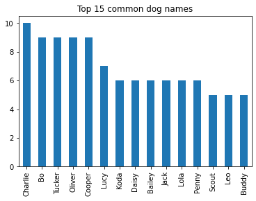

```python
name_list.plot(kind='bar', title = 'Top 15 common dog names',  y="Number of Dogs");
```

The chart shows the distribution of the top 15 dogs common name and we can analyze that the top 5 common names are Charlie, Bo, Tucker, Oliver and Cooper.

### Distribution of dog stages

```python
dog_stages_count = df['dog_stage'].value_counts()
```

```python
df['dog_stage'].value_counts()
```

```
None       1134
pupper      158
doggo        68
puppo        25
floofer       9
Name: dog_stage, dtype: int64
```

[figure not shown]

```python
S = np.arange(8)
dog_stages_count.plot(kind = 'bar', title = 'Most Tweeted Dog Stages')
plt.xticks(S, ('None', 'Pupper', 'Doggo', 'Puppo', 'Doggo,Pupper', 'Floofer', 'Doggo,Puppo', 'Doggo,Floofer'));
```

### Distribution of dog rating

```python
df['rating_numerator'].value_counts().to_frame()
```

|  | rating_numerator |
| --- | --- |
| 12 | 547 |
| 11 | 455 |
| 13 | 339 |
| 14 | 50 |
| 27 | 1 |
| 26 | 1 |
| 15 | 1 |

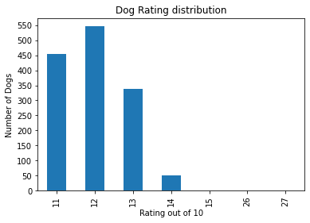

```python
ax = df.rating_numerator.value_counts().sort_index().plot(kind='bar', title = 'Dog Rating distribution')
ax.set_xlabel("Rating out of 10")
ax.set_ylabel("Number of Dogs")
ax.set_yticks([0, 50, 100, 150, 200, 250, 300, 350, 400, 450,500,550]);
```

The chart shows the distribution of the dog rating. We can analyze that out of the rating 10, 547of the dogs have the rating numerators 12/10, 455 of the dogs have the rate 11/10, 339 of the dogs have the rate13/10 and 50 of the dogs have the rate14/10.